# Point Estimates and Sampling Variability

# Parameter Estimation

- We are often interested in **population parameters**.
- Since complete populations are difficult (or impossible) to collect data on, we use **sample statistics** as **point estimates** for the unknown population parameters of interest.
- Sample statistics vary from sample to sample.
- Quantifying how sample statistics vary provides a way to estimate the **margin of error** associated with our point estimate.

# Example 1

If we randomly sample 1,000 adults from each U.S. state, would the sample means of their heights be:

1. very different
2. the same
3. not the same, but only somewhat different

$\star$ The answer is *not the same, but only somewhat different* because of sampling variability.

# Example 2

Suppose the proportion of American adults who support the expansion of solar energy is $p = 0.88$.

1. Is the provided $p$ a population parameter or a sample statistic?
2. Is a randomly selected American adult more or less likely to support the expansion of solar energy?

$\star$ $p=0.88$ is a population parameter because it is talking about all american adults. The proportion is considered a high proportion of support. Thus, a randomly selected american adult is more likely to support solar energy expansion.

# Example 2: Unknown Population Parameter

Suppose that you don’t have access to the population of all American adults, which is a quite likely scenario. In order to estimate the proportion of American adults who support solar power expansion, you might sample from the population and use your sample proportion as the best guess for the unknown population proportion.

- Sample, with replacement, 1000 American adults from the population, and record whether they support solar power or not expansion.
- Find the sample proportion.
- Plot the distribution of the sample proportions.

$\star$ **Key Idea:** After many repeated sampling of the same process as described, the resulting distribution of proportions will be normal.

# Example 2: Point Estimate

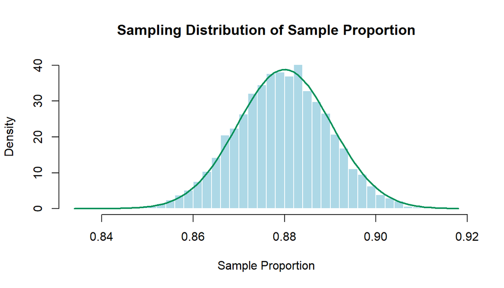

$\dagger$ Based on this distribution, what do you think is the true population proportion?

# Sampling Distributions

**Sampling distributions are never observed**

- In real-world applications, we never actually observe the **sampling distribution**, yet it is useful to always think of a **point estimate** as coming from such a **hypothetical distribution**.

$\star$ **Key Idea:** Understanding the sampling distribution will help us characterize and make sense of the point estimates that we do observe.

# The Normal Distribution (Revisited)

The normal r.v. $X \sim \text{N}(\mu,\sigma^2)$ has infinite possible outcomes (or infinite sized sample space) where $\mu$ is the mean and $\sigma^2$ is the variance ($\sigma$ is the standard deviation) with PDF given the continuous curve below.

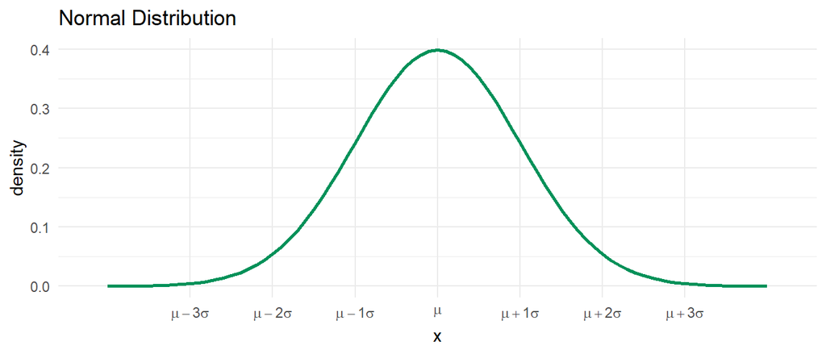

# The 68-95-99.7 Rule (1/3)

**1st standard deviation from the mean**

$$P(\mu - \sigma \le X \le \mu + \sigma)
\approx 0.68$$

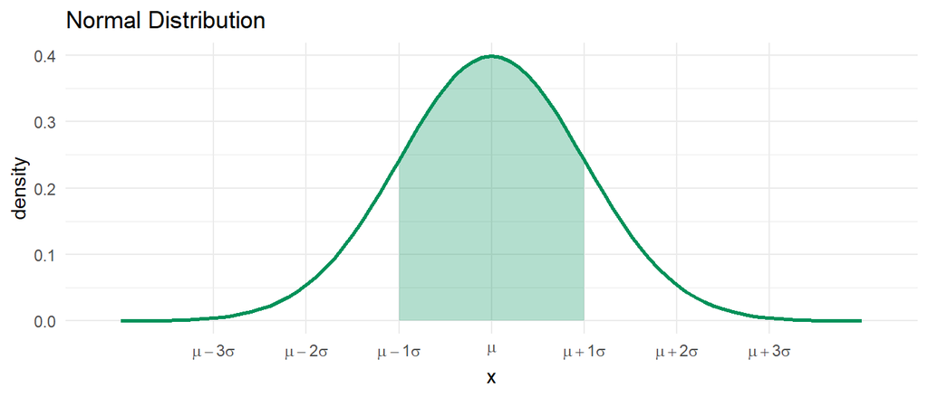

# The 68-95-99.7 Rule (2/3)

**2nd standard deviation from the mean**

$$P(\mu - 2\sigma \le X \le \mu + 2\sigma)
\approx 0.95$$

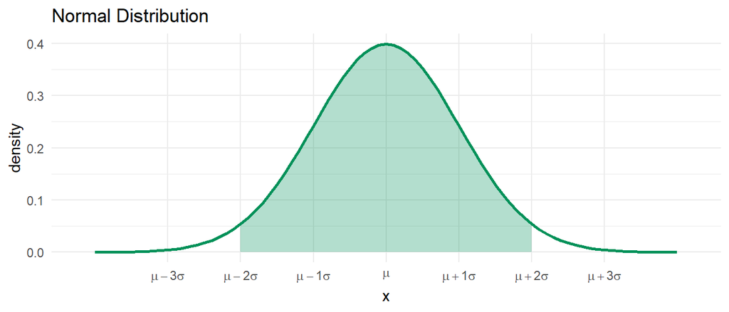

# The 68-95-99.7 Rule (3/3)

**3rd standard deviation from the mean**

$$P(\mu - 3\sigma \le X \le \mu + 3\sigma)
\approx 0.997$$

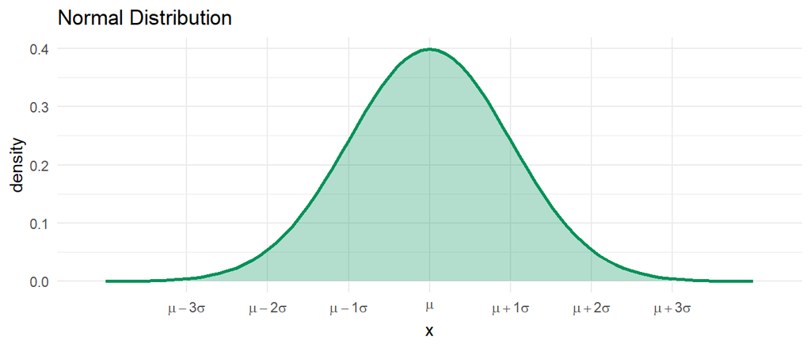

# Total Area Under the Curve

**The Normal PDF satisfies the probability axioms**

$$P(\mu - \infty \le X \le \mu + \infty)
\approx 1$$

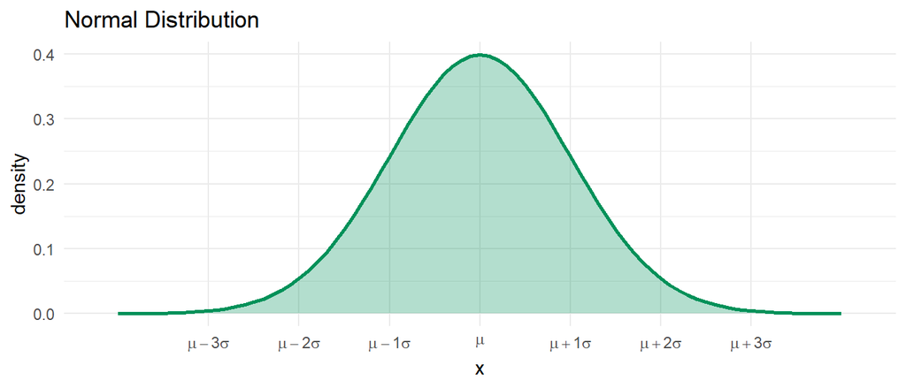

$\star$ **Key Idea:** Because of the axiom that the sum of the probabilities for all outcomes in the sample space is equal to 1, the total area under the Normal PDF is always 1.

# Standard Normal Distribution (1/2)

The **standard normal distribution** is when $\mu=0$ and $s=1$ or $Z \sim \text{N}(0,1)$.

**The transformation formula (the z-score)**

Standardized scores that measure how many standard deviations a value is from the mean.
$$Z = \frac{X -
\mu}{\sigma}$$

# Standard Normal Distribution (2/2)

**The standard normal distribution, $Z \sim \text{N}(0,1)$.**

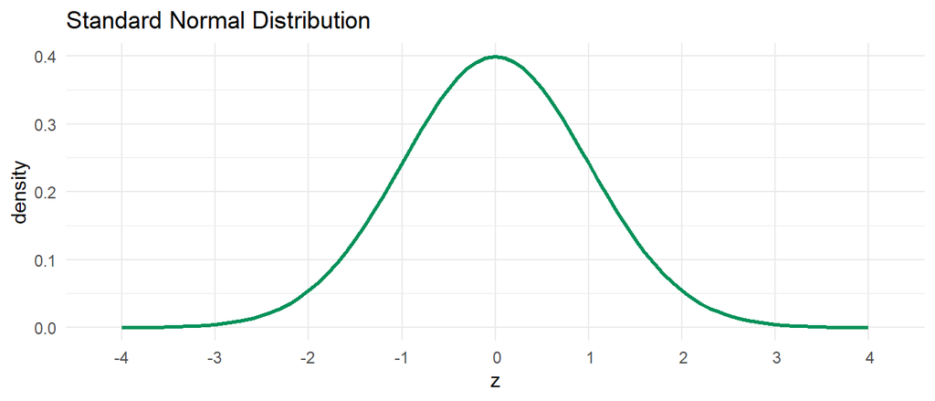

$\star$ **Key Idea:** The standard normal distribution is that it is a normal distribution with a mean of 0 and a standard deviation of 1. It serves as a reference distribution, allowing any normally distributed variable to be standardized.

# CLT Conditions

- **Independence** – Sample values must be independent
- **Identical Distribution** – Variables should be from the same distribution
- **Finite Variance** – The population must have a finite variance
- **Large Sample Size** – A larger sample size improves approximation

# Extending the Framework for other Descriptive Statistics

- The strategy of using a sample statistic to estimate a parameter is quite common, and it’s a strategy that we can apply to other statistics besides a proportion.

**Example:**

Take a random sample of students at a college and ask them how many extracurricular activities they are involved in to estimate the average number (or median number) of extra curricular activities all students in this college are interested in.

$\star$ **Key Idea:** The principles and general ideas of CLT apply to other parameters as well, even if the details change a little.

# Activity: Understanding the CLT

1. Make sure you have a copy of the *W 3/12 Worksheet*. This will be handed out physically and it is also digitally available on Moodle.
2. Work on your worksheet by yourself for 10 minutes. Please read the instructions carefully. Ask questions if anything need clarifications.
3. Get together with another student.
4. Discuss your results.
5. Submit your worksheet on Moodle as a `.pdf` file.

# References

Diez, D. M., Barr, C. D., & Çetinkaya-Rundel, M. (2012). *OpenIntro statistics* (4th ed.). OpenIntro. https://www.openintro.org/book/os/